# Principle Component Analysis of `c_m_TRANSFORMED.csv` for Myoglobin Vs. Control

## Introduction

This chapter describes the use, intuition and a functional understanding when using PCA on the `c_m_TRANSFORMED.csv` myoglobin/control dataset. Principle Component Analysis (PCA) is very popular and commonly used during the Exploratory Data Analysis (EDA) phase to provide information on the proportions of variance found within a dataset.

> The major goal of principal components analysis is to reveal hidden structure in a dataset. In so doing, we may be able to;[^1]
> 1. identify how different variables work together to create the dynamics of the system
> 2. reduce the dimensionality of the data
> 3. decrease redundancy in the data
> 4. filter some of the noise in the data
> 5. compress the data
> 6. prepare the data for further analysis using other techniques

## Finding the Covariance Matrix[^2]

[Covariance](http://mathworld.wolfram.com/Covariance.html) provides a measure of the strength of the correlation between two or more sets of random variates.

#### Covariance of two variables

$$cov(X, Y) ~=~ \frac{1}{N} \sum_{i=1}^N (x_i - \bar x) (y_i - \bar y)$$

#### Covariance of matrices

Determining the covariance using matrix, $\large M$ using linear algebra notation is;[^3]

1. Find the column means of the matrix, $M_{means}$.
2. Find the difference matrix, $D ~=~ M - M_{means}$.
3. Finally calculate the covariance matrix:

$$cov ~ (M) ~=~ \frac{1}{N-1} ~ D^T ~ D, ~~~ where ~~~ D = M - M_{means}$$

PCA is linked to the singular value decomposition (SVD) used when determining eigenvectors and eigenvalues.

> Singular value decomposition says that every n x p matrix can be written as the product of three matrices: $A = U \Sigma V^T$ where:[^4]
> 1. $U$ is an orthogonal n x n matrix.
> 2. $\Sigma$ is a diagonal n x p matrix. In practice, the diagonal elements are ordered so that $\Sigma_{ii} ~\geqq~ \Sigma_{jj}$ for all i < j.
> 3. $V$ is an orthogonal p x p matrix and $V^T$ represents a matrix transpose.

> The SVD represents the essential geometry of a linear transformation. It tells us that every linear transformation is a composition of three fundamental actions. Reading the equation from right to left:
> 1. The matrix $V$ represents a rotation or reflection of vectors in the p-dimensional domain.
> 2. The matrix $\Sigma$ represents a linear dilation or contraction along each of the p coordinate directions. If n ≠ p, this step also canonically embeds (or projects) the p-dimensional domain into (or onto) the n-dimensional range.
> 3. The matrix $U$ represents a rotation or reflection of vectors in the n-dimensional range.

The intuition for understanding PCA is fairly straightforward. Consider the 2-dimensional data cloud of points or observations in an hypothetical experiment, as seen in figure #1. Considering this data, the variances along both the x and y dimensions can be calculated. However, given the data shown, there is a rotation of that x-y plane which will present the data showing its greatest variance. This variance will reside on an axis analogous to points on an Ordinary Least Squares (OLS) line. This axis is called the *first principle component* followed by the second principal component and so on.

Unlike an OLS calculation, PCA will determine not only the first and largest variance of your data set but it will through the rotation and transform your dataset via linear algebra, calculating N variances within you dataset, where N is equal to the number of features in the dataset. The second principle component will be calculated only along a coordinate axis which is perpendicular (orthogonal or orthonormal) to the first. Each subsequent principle component will then be calculated along axises which are orthogonal to each other. A further benefit of using PCA is that the variances it reports will be ranked in order from highest to lowest.[^5]

For more information on Eigenvalues, Eigenvectors and Eigen decomposition I suggest:

1. [CodeEmporium](https://youtu.be/9oSkUej63yk)
2. [Victor Lavrenko](https://youtu.be/IbE0tbjy6JQ)

### Two-dimensional example of PCA from random data:

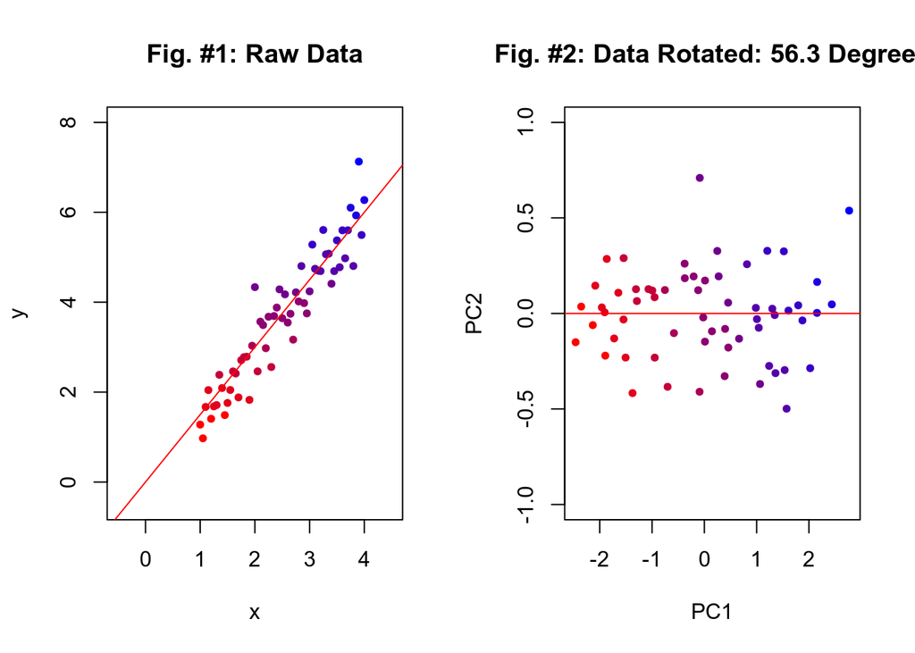

NOTE: If you would like to investigate this phenomenon, the code below will generate a NO frills graphical plot.

```
set.seed(1000)
x = seq(1, 4, 0.05)
y = 1.5*x + rnorm(61, mean = 0, sd = 0.5)

xy_covar <- cov(cbind(x, y))
xy_eigen <- eigen(xy_covar)

plot(x, y)
plot(xy_pca$x[, 1], xy_pca$x[, 2])
```

Questions:  
1. What information can be gleaned from PCA?  
2. What do the center and scale arguments do in the `prcomp` command?

There are many R-packages which will carry out the steps for PCA all behind the ‘scenes’ but giving no greater understanding for beginners. For example, `stats::prcomp`, `stats::princomp` are most commonly used. However, there are *several dozen* packages. A key word search for ‘PCA’ at [R-cran](https://cran.r-project.org/web/packages/available_packages_by_name.html) provides 78 matches, as of November, 2019.

## Data centering / scaling / normalization

While determining the variance of your dataset it should be clear that the order of magnitude of your data features matters greatly. The reasons for this should be clear that if one axis is in 1,000’s while the second axis is between 1 and 10, the larger scale will obviously have a greater variance.

There are four common methods for **scaling** data:

| No. | Scaling Method | Formula |
| --- | --- | --- |
| 1 | Centering | $f(x) ~=~ \large x - \bar x$ |
| 2 | Scaling between [0, 1] | $f(x) ~=~ \Large \frac {x - min(x)} {max(x) - min(x)}$ |
| 3 | Scaling between [a, b] | $f(x) ~=~ \large (b - a)* \Large \frac {x - min(x)} {max(x) - min(x)} + a$ |
| 4 | Normalizing | $f(x) ~=~ \Large \frac {x - mean(x)} {\sigma_x}$ |

## Histograms of Scaled Vs Unscaled data

Investigating the differences between the amino acid Phenylalanine (F) before and after 2 scaling methods.

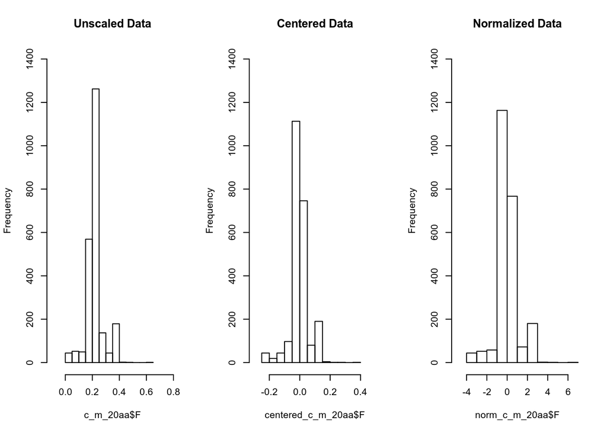

Investigating the plots above, the main idea to recognize is that the data has not been fundamentally changed, simply ‘shifted and stretched’ or more accurately transformed. In fact, any visible changes of the distributions can be accounted for by differing binnings.

## Principle component analysis using `norm_c_m_20aa`

```r
start_time <- Sys.time() # Start timer

c_m_20_PCA = prcomp(norm_c_m_20aa)

end_time <- Sys.time()   # End timer
end_time - start_time    # Display time
```

```
## Time difference of 0.008529663 secs
```

## Screeplot: Eigenvalues Vs Principal Components

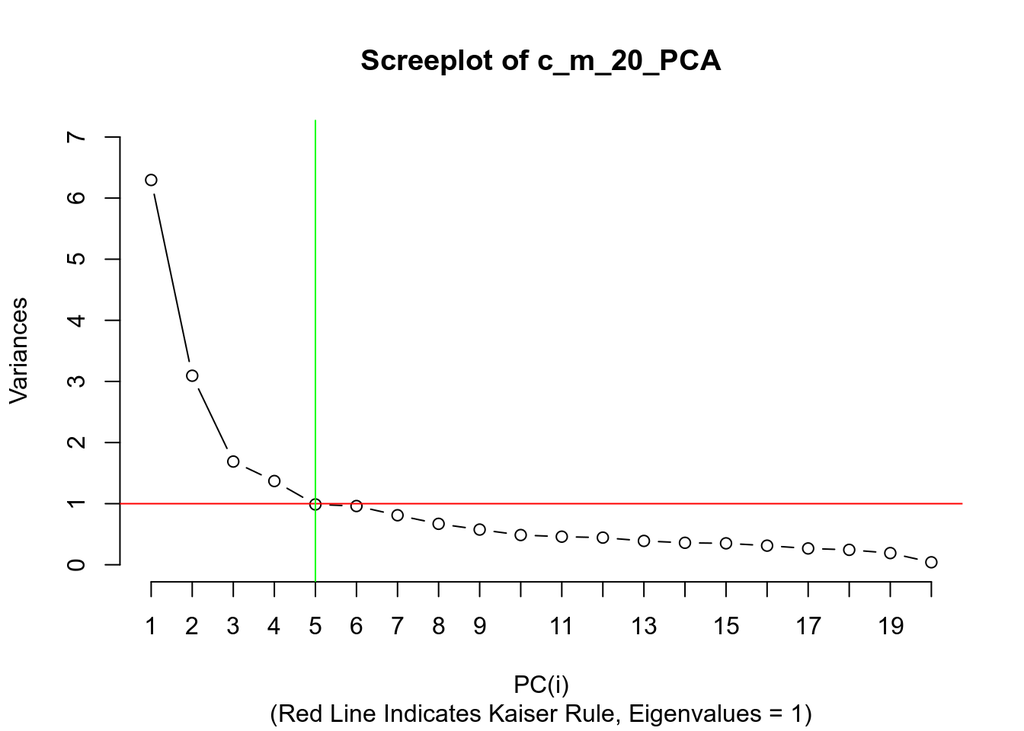

## Plot: Cumulative Proportion of Variance Vs Principal Components

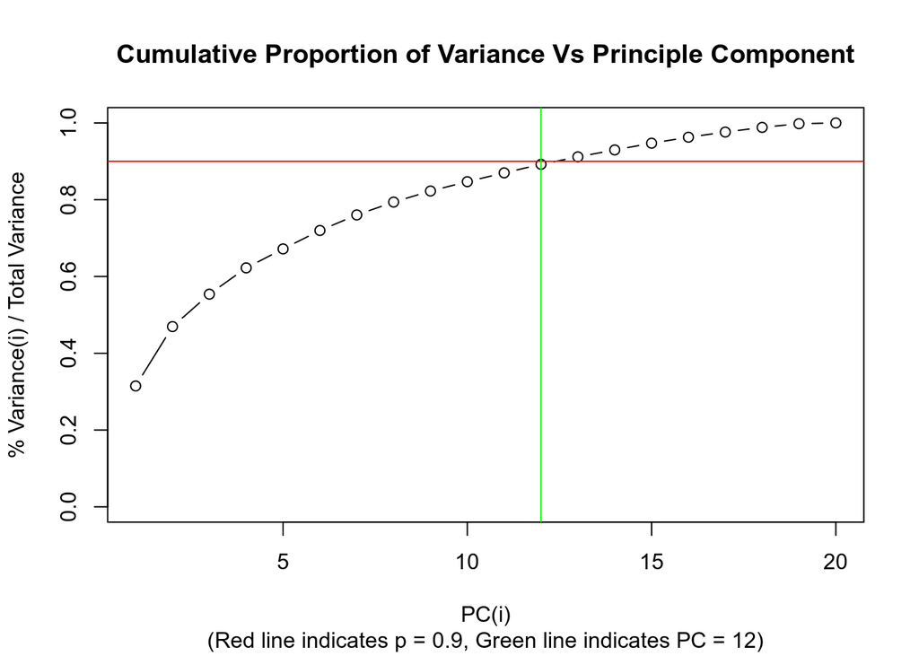

## Biplots

### Biplot 1: PC1 Vs PC2 with ‘Class’ by color labels

- Black indicates control protein set, Class = 0
- Blue indicates myoglobin protein set, Class = 1

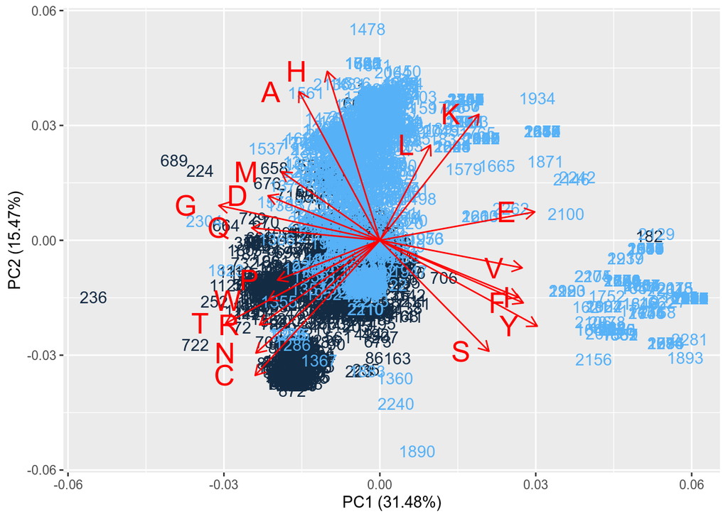

### Biplots 2: Determination Of 4 Rule Set For Outliers

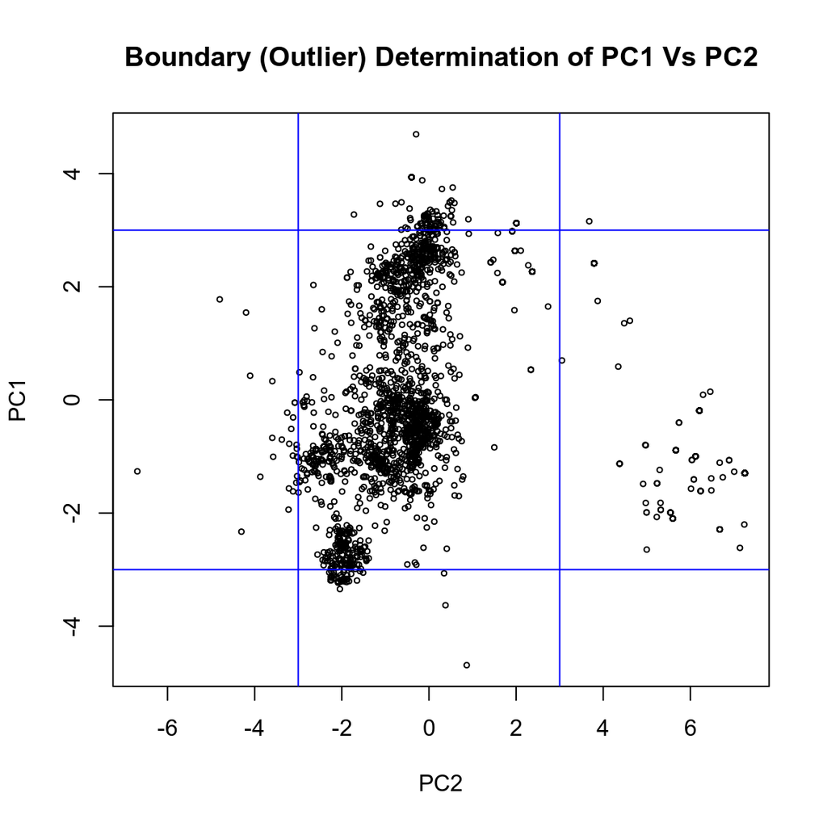

## Obtain Outliers From Biplot #2: PC1 Vs PC2

#### Number of Outliers from PC-1

Rule Set:

1. Outlier_1: c_m_20_PCA$x[, 1] > 3 std dev
2. Outlier_2: c_m_20_PCA$x[, 1] < -3 std dev

```r
outliers_PC1 <- which((c_m_20_PCA$x[, 1] > 3) | (c_m_20_PCA$x[, 1] < -3))
length(outliers_PC1)
```

```
## [1] 285
```

```r
# outliers_PC1
```

#### Number of Outliers from PC-2

Rule Set:

3. Outlier_3: c_m_20_PCA$x[, 2] > 3 std dev
4. Outlier_4: c_m_20_PCA$x[, 2] < -3 std dev

```r
outliers_PC2 <- which((c_m_20_PCA$x[, 2] > 3) | (c_m_20_PCA$x[, 2] < -3))
length(outliers_PC2)
```

```
## [1] 177
```

```r
# outliers_PC2
```

### List of all outliers (union and sorted) found using rule set 1 through 4

- the list of total outliers is derived by taking the `union` of `outliers_PC1` and `outliers_PC2` and then using `sort`.

```
## [1] 461
```

```
## [1]   1   8  72 115 179 180
```

It is important to remember and understand that this list of “total_pca_1_2_outliers” includes BOTH negative and positive controls. The groupings are as follows:

| Group | Numbering |
| --- | --- |
| Controls | {1, …, 1217} |
| Positive samples | {1218, …, 2341} |

## Conclusions

Principal Component Analysis is an excellent choice to include during Exploratory Data Analysis.

### Screeplot

There are two plots which are commonly used to determine the number of principal components that a researcher would generally accept as useful. The eigenvalues derived from PCA are proportional to the variances which they represent, and depending on the strategy used to calculate them, the eigenvalues are equal to the variances of the components.

The second plot describes the cumulative proportion of variance versus the principle component. This graphic shows how much each principal component describes from the entire cumulative variances or total squared error.

$$Cumlative ~ Proportion ~of ~Variance ~=~ \frac{\sigma_i^2}{\sum_{i=1}^N \sigma_i^2}$$

Here again there are several criteria regarding how best to use the information from the is plot. The first of which is Cattell’s heuristic. Cattell advises to use the principal component that is above the elbow of the curve. The second heuristic is keeping the total number of factors that best explains 80%-95% of the variance. There is no hard fast rule at this time. Whereas some researchers only use the first three factors or none at all.[^7]

If we investigate the ‘cumulative proportion of variance’ plot we see an arbitrary line on the Y-axis which denotes the 90% mark. At this point the plot suggests that a researcher could use largest 12 of the variances from the PCA.

### Biplots

I have chosen for the sake of brevity to analyze the PCA biplot of the first and second principal components.

[figure not shown]

#### Biplot 1: PC1 Vs PC2 with color ‘Class’ labels

- Black indicates control protein set, Class = 0
- Blue indicates myoglobin protein set, Class = 1
[^1]: Principal Components Analysis:A How-To Manual for R, Emily Mankin, http://people.tamu.edu/~alawing/materials/ESSM689/pca.pdf
[^2]: Trevor Hastie, Robert Tibshirani, Jerome Friedman, ‘The Elements of Statistical Learning; Data Mining, Inference, and Prediction’, Second Edition, 2009, Springer, DOI:10.1007/978-0-387-84858-7
[^3]: http://mathworld.wolfram.com/Covariance.html
[^4]: https://blogs.sas.com/content/iml/2017/08/28/singular-value-decomposition-svd-sas.html
[^5]: Brian Everitt, Torsten Hothorn, An Introduction to Applied Multivariate Analysis with R, 2011, Springer, DOI:10.1007/978-1-4419-9650-3
[^6]: Cattell, Raymond (1966). “The scree test for the number of factors”. Multivariate Behavioral Research. 1 (2): 245–76. doi:10.1207/s15327906mbr0102_10. PMID 26828106
[^7]: Nicole Radzill, personal communication.